# Evaluation of item fit

KB christensen, M Horton

16 jan 2019

Item fit statistics are the most commonly reported feature in Rasch validation studies. Several item fit statistics have been developed, however the most widely used are the infit and outfit mean square item fit statistics that are in Winsteps the fit residual, Chi-square and ANOVA item fit statistics from RUMM2030.

Item fit statistics test the assumption of monotonicity, i.e. that the expected value of an item score increases when the values of the latent variable increases.

We illustrate the evaluation of item fit by calculating two different item fit statistics, and by graphical evaluation # getting ready

We install packages (this is only needed if they are not already installed)

```r
options(repos="https://cran.rstudio.com" )
install.packages("eRm")
install.packages("PP")
install.packages("mRm")
install.packages("psychotools")
install.packages("corrplot")
```

# Evaluating the item fit in the AMTS data using Infit and outfit

Infit and outfit are mean-square residual summary statistics that range from zero to infinity. The expected value, under the null hypothesis that data fit the Rasch model, is one. Values greater than one indicate under-discrimination while values below one over-discrimination, both of which violate Rasch model assumptions.

```r
data("amts")
names(amts)
```

```
 [1] "id"       "agegrp"   "sex"      "age"      "time"     "address"
 [7] "name"     "year"     "dob"      "month"    "firstww"  "monarch"
[13] "countbac"
```

```r
AMTS.items <- amts[,-c(1,2,3)]
rm <- RM(AMTS.items)
out_infit(rm)
```

```
         Outfit se    pvalue sig   Infit se    pvalue sig
age      0.635  0.261 0.162        0.858 0.125 0.256
time     1.094  0.188 0.617        1.028 0.108 0.798
address  1.408  0.277 0.141        1.15  0.09  0.097   .
name     0.799  0.261 0.442        0.904 0.125 0.443
year     0.712  0.182 0.113        0.874 0.107 0.238
dob      0.835  0.494 0.738        1.099 0.181 0.583
month    0.585  0.17  0.014   *    0.673 0.104 0.002   **
firstww  1.305  0.207 0.141        1.191 0.112 0.089   .
monarch  0.882  0.179 0.511        0.957 0.106 0.683
countbac 1.429  0.17  0.012   *    1.3   0.104 0.004   **
```

these flag the two items `month` and `countbac` as anomalies. It is questionable if we can trust the asymptotic distribution used for computation of $p$-values and for this reason is is preferable to use bootstrap

```r
boot_fit(rm,350)
```

```
 Number of bootstrap samples:  50, 100, 150, 200, 250, 300, 350,
```

```
         Outfit pvalue sig    Infit pvalue sig
age      0.635  0.061   .     0.858 0.161
time     1.094  0.558         1.028 0.786
address  1.408  0.2           1.15  0.032   *
name     0.799  0.312         0.904 0.316
year     0.712  0.087   .     0.874 0.202
dob      0.835  0.786         1.099 0.403
month    0.585  0      ***    0.673 0      ***
firstww  1.305  0.119         1.191 0.043   *
monarch  0.882  0.549         0.957 0.719
countbac 1.429  0.045   *     1.3   0.012   *
```

# Evaluating the item fit in the AMTS data using item-restscore correlation

Item-total correlations and item-restscore correlations (called ‘corrected’ item-total correlations) are routinely reported in classical test theory. Kreiner (2011) used the simple structure in the Rasch model to compute the expected values of the item-restscore correlation

```r
item_restscore(rm)
```

```
         observed expected se     pvalue sig
age      0.8406   0.7511   0.0433 0.0391 *
time     0.7087   0.7374   0.0660 0.6631
address  0.5955   0.6885   0.0733 0.2047
name     0.8012   0.7511   0.0534 0.3486
year     0.8214   0.7357   0.0419 0.0408 *
dob      0.7816   0.7804   0.0647 0.9855
month    0.8860   0.7311   0.0371 0.0000 ***
firstww  0.6247   0.7415   0.0766 0.1275
monarch  0.7772   0.7349   0.0500 0.3971
countbac 0.5930   0.7311   0.0729 0.0580 .
```

```r
item_restscore(rm)
```

```
         observed expected se     pvalue sig
age      0.8406   0.7511   0.0433 0.0391 *
time     0.7087   0.7374   0.0660 0.6631
address  0.5955   0.6885   0.0733 0.2047
name     0.8012   0.7511   0.0534 0.3486
year     0.8214   0.7357   0.0419 0.0408 *
dob      0.7816   0.7804   0.0647 0.9855
month    0.8860   0.7311   0.0371 0.0000 ***
firstww  0.6247   0.7415   0.0766 0.1275
monarch  0.7772   0.7349   0.0500 0.3971
countbac 0.5930   0.7311   0.0729 0.0580 .
```

# plots

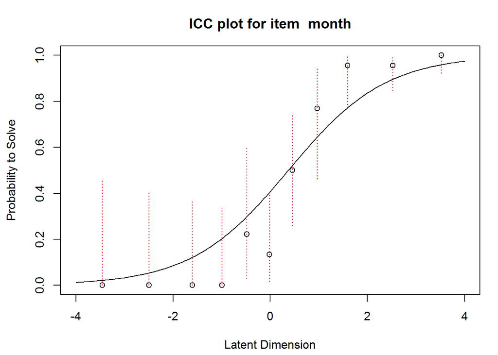

```r
AMTS.items.complete <- AMTS.items[complete.cases(AMTS.items),]
rm.complete <- RM(AMTS.items.complete)
plotICC(rm.complete,
item.subset = c(7),
empICC = list("raw"),
empCI = list()
)
```